# Exploratory Data Analysis

```r
library(tidyverse)
```

```r
library(corrplot)
library(ggvis)
library(GGally)
library(ggExtra)
```

```r
song_table = read.csv('genre_music.csv',header = TRUE,sep = ",")
head(song_table)
```

```
##                   track           artist danceability energy key loudness mode
## 1 Jealous Kind Of Fella    Garland Green        0.417  0.620   3   -7.727    1
## 2         Initials B.B. Serge Gainsbourg        0.498  0.505   3  -12.475    1
## 3          Melody Twist      Lord Melody        0.657  0.649   5  -13.392    1
## 4         Mi Bomba Sonó       Celia Cruz        0.590  0.545   7  -12.058    0
## 5           Uravu Solla      P. Susheela        0.515  0.765  11   -3.515    0
## 6             Beat n. 3  Ennio Morricone        0.697  0.673   0  -10.573    1
##   speechiness acousticness instrumentalness liveness valence   tempo duration_s
## 1      0.0403        0.490         0.00e+00   0.0779   0.845 185.655    173.533
## 2      0.0337        0.018         1.07e-01   0.1760   0.797 101.801    213.613
## 3      0.0380        0.846         4.42e-06   0.1190   0.908 115.940    223.960
## 4      0.1040        0.706         2.46e-02   0.0610   0.967 105.592    157.907
## 5      0.1240        0.857         8.72e-04   0.2130   0.906 114.617    245.600
## 6      0.0266        0.714         9.19e-01   0.1220   0.778 112.117    167.667
##   time_signature chorus_hit sections popularity decade genre
## 1              3   32.94975        9          1    60s   edm
## 2              4   48.82510       10          0    60s   pop
## 3              4   37.22663       12          0    60s   pop
## 4              4   24.75484        8          0    60s   pop
## 5              4   21.79874       14          0    60s   r&b
## 6              4   65.48604        7          0    60s   pop
```

First to check the data types in the data frame:

```r
str(song_table)
```

```
## 'data.frame':    41099 obs. of  20 variables:
##  $ track           : chr  "Jealous Kind Of Fella" "Initials B.B." "Melody Twist" "Mi Bomba Sonó" ...
##  $ artist          : chr  "Garland Green" "Serge Gainsbourg" "Lord Melody" "Celia Cruz" ...
##  $ danceability    : num  0.417 0.498 0.657 0.59 0.515 0.697 0.662 0.72 0.545 0.511 ...
##  $ energy          : num  0.62 0.505 0.649 0.545 0.765 0.673 0.272 0.624 0.22 0.603 ...
##  $ key             : int  3 3 5 7 11 0 0 5 2 2 ...
##  $ loudness        : num  -7.73 -12.47 -13.39 -12.06 -3.52 ...
##  $ mode            : int  1 1 1 0 0 1 1 0 0 1 ...
##  $ speechiness     : num  0.0403 0.0337 0.038 0.104 0.124 0.0266 0.0313 0.0473 0.0828 0.028 ...
##  $ acousticness    : num  0.49 0.018 0.846 0.706 0.857 0.714 0.36 0.795 0.582 0.0385 ...
##  $ instrumentalness: num  0.00 1.07e-01 4.42e-06 2.46e-02 8.72e-04 9.19e-01 2.28e-01 0.00 2.39e-01 1.67e-06 ...
##  $ liveness        : num  0.0779 0.176 0.119 0.061 0.213 0.122 0.0963 0.488 0.269 0.142 ...
##  $ valence         : num  0.845 0.797 0.908 0.967 0.906 0.778 0.591 0.887 0.386 0.685 ...
##  $ tempo           : num  186 102 116 106 115 ...
##  $ duration_s      : num  174 214 224 158 246 ...
##  $ time_signature  : int  3 4 4 4 4 4 4 4 4 4 ...
##  $ chorus_hit      : num  32.9 48.8 37.2 24.8 21.8 ...
##  $ sections        : int  9 10 12 8 14 7 7 8 6 9 ...
##  $ popularity      : int  1 0 0 0 0 0 0 1 0 1 ...
##  $ decade          : chr  "60s" "60s" "60s" "60s" ...
##  $ genre           : chr  "edm" "pop" "pop" "pop" ...
```

Then to check for missing values:

```r
#Check for missing values
colSums(is.na(song_table))
```

```
##            track           artist     danceability           energy
##                0                0                0                0
##              key         loudness             mode      speechiness
##                0                0                0                0
##     acousticness instrumentalness         liveness          valence
##                0                0                0                0
##            tempo       duration_s   time_signature       chorus_hit
##                0                0                0                0
##         sections       popularity           decade            genre
##                0                0                0                0
```

To make the classes more clear, the 0 and 1 were changes to Flop and Hit respectively. The amount of each class was then checked.

```r
#change popularity to Hit or Flop
song_table$popularity_f = as.character(song_table$popularity)
song_table$popularity_f[song_table$popularity_f == 0] = "Flop"
song_table$popularity_f[song_table$popularity_f == 1] = "Hit"

#split of Hit or Flop in dataset
pop_count = song_table %>% group_by(popularity_f) %>% dplyr::summarize(ncount = n())

pop_count
```

```
## # A tibble: 2 × 2
##   popularity_f ncount
##   <chr>         <int>
## 1 Flop          20551
## 2 Hit           20548
```

There is a nearly equal split between the classes so there is no class imbalance issue. Next taking a look at the distribution of the numerical data.

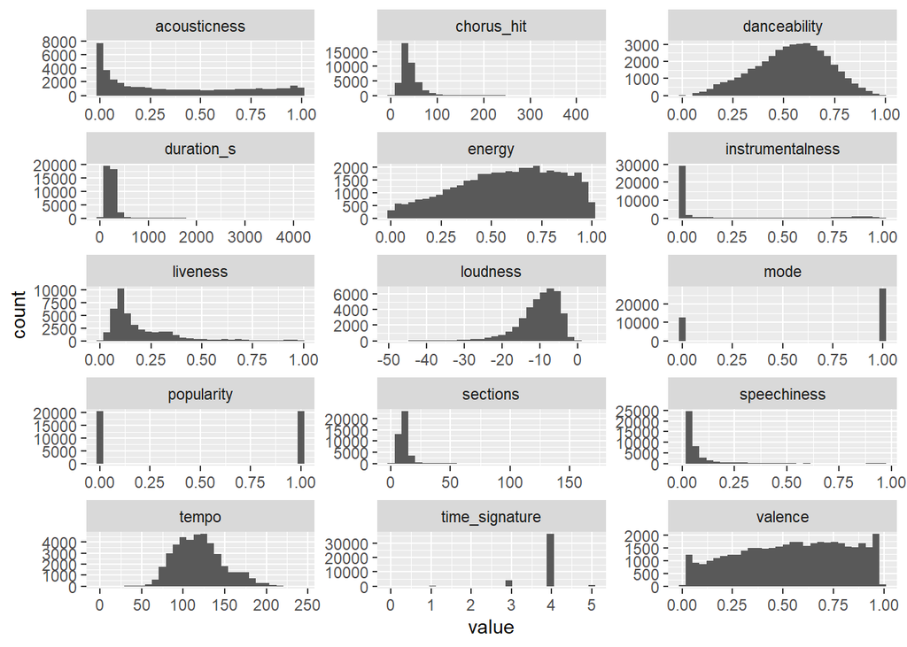

```r
#Data that is numbers
num_data = song_table[,sapply(song_table,is.numeric)]

gather(num_data) %>% ggplot(aes(x=value)) + geom_histogram() + facet_wrap(~key, scales='free', ncol=3)
```

Key, mode,sections,and time signiture are all ints and can be easily converted to factors.

Looking at the discrete values, Decade and Genre

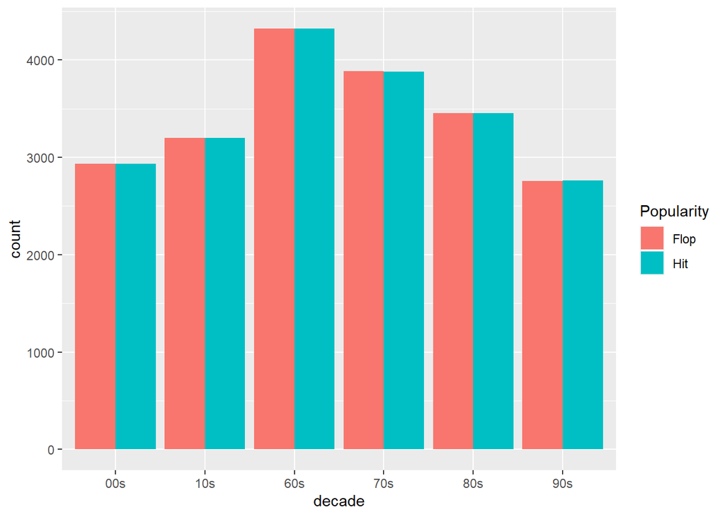

```r
#Check distribution of decade vs Hit or Flop
ggplot(song_table,aes(x=decade,fill = factor(popularity)))+
  geom_bar(position = "dodge")+
  scale_fill_discrete(name = "Popularity", labels = c("Flop", "Hit"))
```

The decade does not make a difference if the song is a hit or flop.

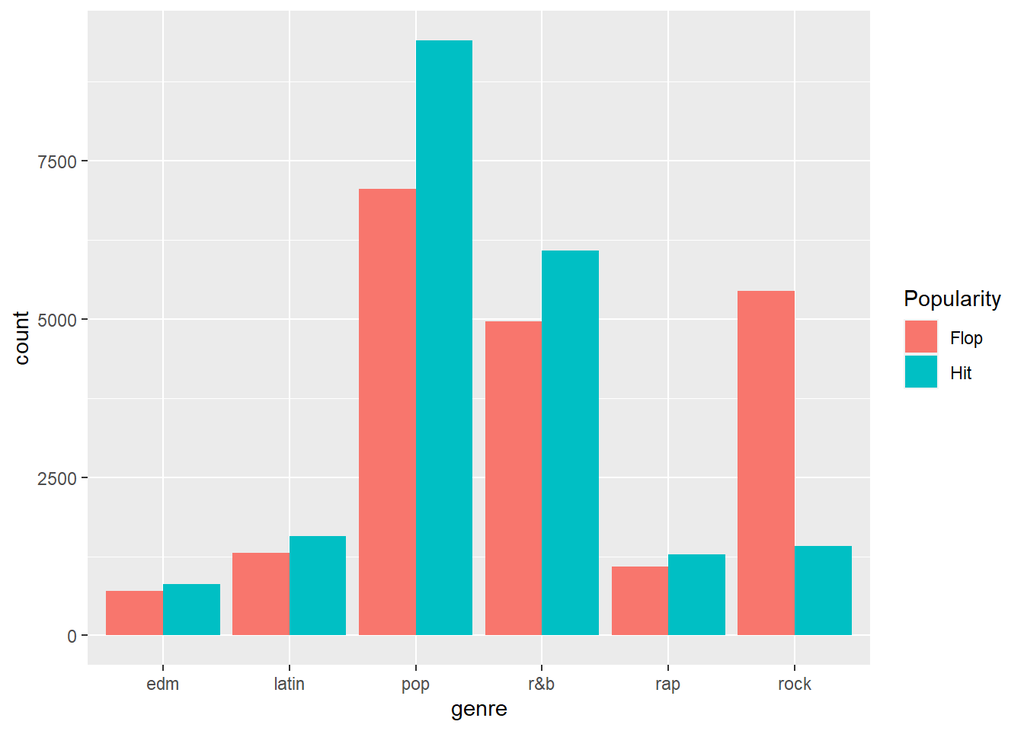

```r
#Check genre distribution
ggplot(song_table,aes(x=genre,fill=factor(popularity)))+
  geom_bar(position = "dodge")+
  scale_fill_discrete(name = "Popularity", labels = c("Flop", "Hit"))
```

There is a large difference in the number of tracks per genre. Checking the percent of each genre that is a Hit should give a better idea if one genre is a better predictor than the others.

```r
Pop_genre = song_table %>% group_by(genre,popularity_f) %>% summarize(ncount = n()) %>% mutate(perc = ncount/sum(ncount))
Hit_genre = Pop_genre[Pop_genre$popularity_f == "Hit",]

Hit_genre
```

```
## # A tibble: 6 × 4
## # Groups:   genre [6]
##   genre popularity_f ncount  perc
##   <chr> <chr>         <int> <dbl>
## 1 edm   Hit             813 0.537
## 2 latin Hit            1566 0.546
## 3 pop   Hit            9403 0.571
## 4 r&b   Hit            6077 0.550
## 5 rap   Hit            1280 0.541
## 6 rock  Hit            1409 0.206
```

Only 20.5% of all rock songs become hits. Other than rock, all genres have a similar percentage of songs that became Hits.

A correlation table was created to check if there are any relations between the input variables and the output variable.

```r
#search for correlations
cor_table = cor(num_data)
cor_table
```

```
##                  danceability       energy          key      loudness
## danceability       1.00000000  0.206035978  0.015432672  0.2739970987
## energy             0.20603598  1.000000000  0.022598049  0.7726110206
## key                0.01543267  0.022598049  1.000000000  0.0084833452
## loudness           0.27399710  0.772611021  0.008483345  1.0000000000
## mode              -0.03273989 -0.033907097 -0.140398240  0.0003836035
## speechiness        0.15636198  0.122360000  0.026554467  0.0691146071
## acousticness      -0.26112171 -0.715083712 -0.024239573 -0.5665030317
## instrumentalness  -0.30183360 -0.208112978 -0.013119985 -0.3742059492
## liveness          -0.11527547  0.157796952  0.000638586  0.0866756469
## valence            0.55384460  0.341398310  0.007748265  0.2717057161
## tempo             -0.06658774  0.224106621  0.001116292  0.1695057977
## duration_s        -0.06291464  0.011961164  0.015480159 -0.0497331819
## time_signature     0.19181397  0.196220995  0.004755683  0.1657475104
## chorus_hit        -0.03622727  0.009659709  0.010261733 -0.0133711167
## sections          -0.05852761 -0.040128859  0.006770826 -0.0799464306
## popularity         0.34601993  0.177117148  0.009922806  0.2859721077
##                           mode  speechiness acousticness instrumentalness
## danceability     -0.0327398910  0.156361975  -0.26112171      -0.30183360
## energy           -0.0339070970  0.122360000  -0.71508371      -0.20811298
## key              -0.1403982400  0.026554467  -0.02423957      -0.01311999
## loudness          0.0003836035  0.069114607  -0.56650303      -0.37420595
## mode              1.0000000000 -0.059758329   0.05002802      -0.07596829
## speechiness      -0.0597583293  1.000000000  -0.08384297      -0.08406745
## acousticness      0.0500280220 -0.083842970   1.00000000       0.20408288
## instrumentalness -0.0759682904 -0.084067449   0.20408288       1.00000000
## liveness          0.0087806134  0.131380735  -0.03073127      -0.05055360
## valence           0.0356129067  0.001521327  -0.19529572      -0.28697696
## tempo             0.0270883402  0.036730223  -0.17971878      -0.05359510
## duration_s       -0.0747437348  0.007707605  -0.07038914       0.10651053
## time_signature   -0.0093871828  0.021087258  -0.18824164      -0.07813960
## chorus_hit       -0.0226040031  0.012989858  -0.01246828       0.04869502
## sections         -0.0570163352 -0.008571840  -0.01691742       0.08116670
## popularity        0.0796329843 -0.040935887  -0.24595220      -0.40756039
##                       liveness       valence        tempo   duration_s
## danceability     -0.1152754650  0.5538445969 -0.066587738 -0.062914636
## energy            0.1577969520  0.3413983102  0.224106621  0.011961164
## key               0.0006385860  0.0077482653  0.001116292  0.015480159
## loudness          0.0866756469  0.2717057161  0.169505798 -0.049733182
## mode              0.0087806134  0.0356129067  0.027088340 -0.074743735
```

[output cut: 13 more lines]

```
## energy              0.196220995  0.009659709 -0.040128859  0.177117148
## key                 0.004755683  0.010261733  0.006770826  0.009922806
## loudness            0.165747510 -0.013371117 -0.079946431  0.285972108
## mode               -0.009387183 -0.022604003 -0.057016335  0.079632984
## speechiness         0.021087258  0.012989858 -0.008571840 -0.040935887
## acousticness       -0.188241643 -0.012468282 -0.016917421 -0.245952195
## instrumentalness   -0.078139599  0.048695016  0.081166701 -0.407560390
## liveness            0.004804478  0.037967719 -0.011708253 -0.051484178
## valence             0.155806256 -0.059120163 -0.133475871  0.251117415
## tempo               0.007596031 -0.056084742  0.024867706  0.032581788
## duration_s          0.018341558  0.093844012  0.888942113 -0.073805573
## time_signature      1.000000000 -0.011281849  0.008333978  0.104941333
## chorus_hit         -0.011281849  1.000000000 -0.085964761 -0.046416438
## sections            0.008333978 -0.085964761  1.000000000 -0.059992985
## popularity          0.104941333 -0.046416438 -0.059992985  1.000000000
```

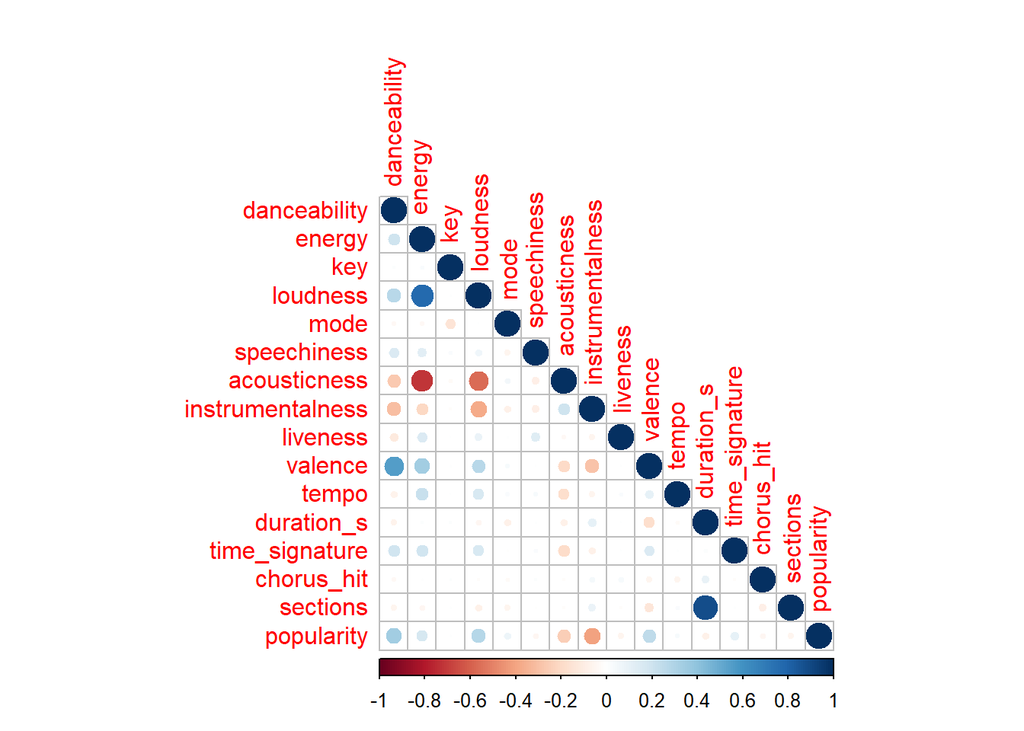

```r
corrplot(cor_table,type = "lower")
```

There is a strong inverse correlation between acousticness and energy and loudness. For the classification model only acousticness will be kept.

The other strong correlation is between sections and duration_s. Only sections will be kept for the model.

Looking at correlations between genres and other variables to see if genre can be classified

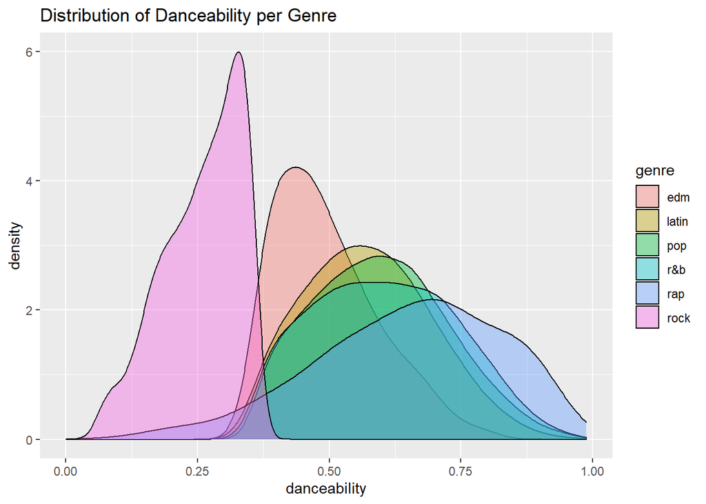

```r
ggplot(song_table,aes(x=danceability,fill=genre))+
  geom_density(adjust = 1.5,alpha=.4)+
  labs(title="Distribution of Danceability per Genre")
```

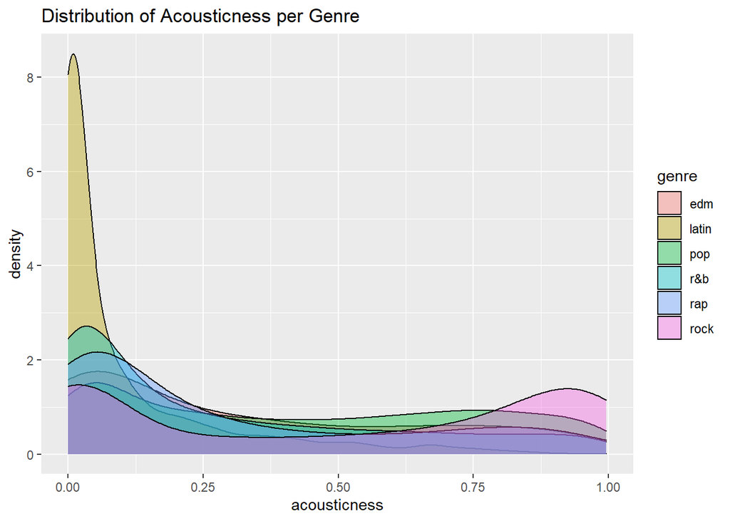

```r
ggplot(song_table,aes(x=acousticness,fill=genre))+
  geom_density(adjust = 1.5,alpha=.4)+
  labs(title="Distribution of Acousticness per Genre")
```

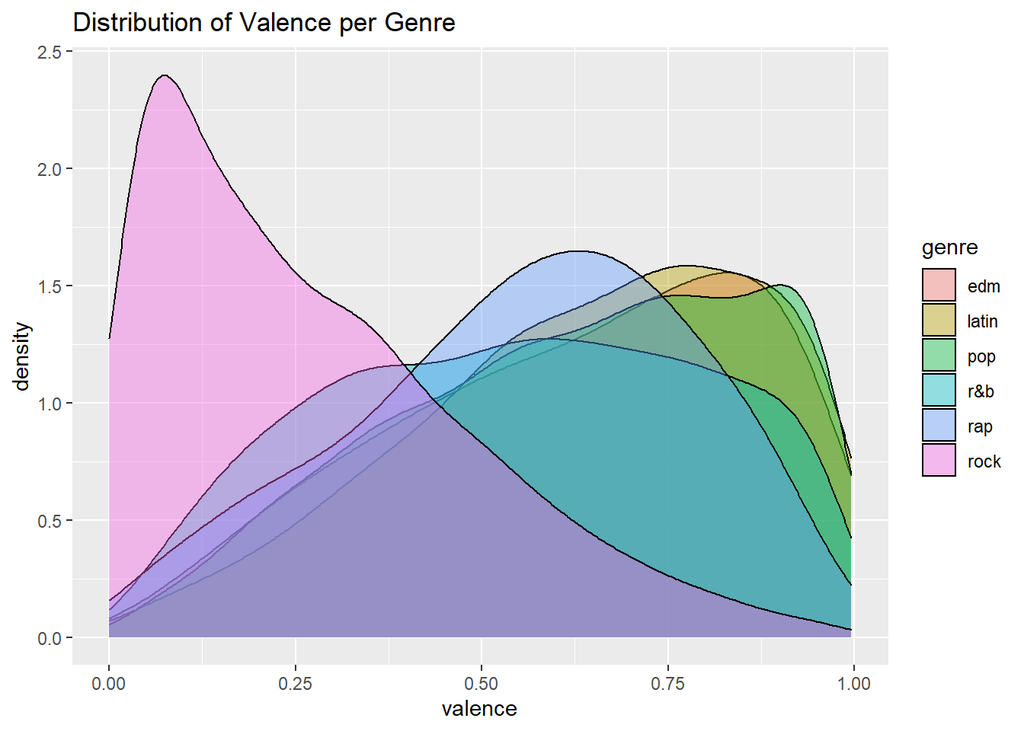

```r
ggplot(song_table,aes(x=valence,fill=genre))+
  geom_density(adjust = 1.5,alpha=.4)+
  labs(title="Distribution of Valence per Genre")
```

There is a large amount of overlap for the distribution of variable for genre so a classification of genre would be difficult/innacurate.

Next I took a look at the variables that had the strongest correlation to popularity, loudness and danceability. Instrumnetalness was not looked at because the majority of the songs have the simialr instrumentalness values.

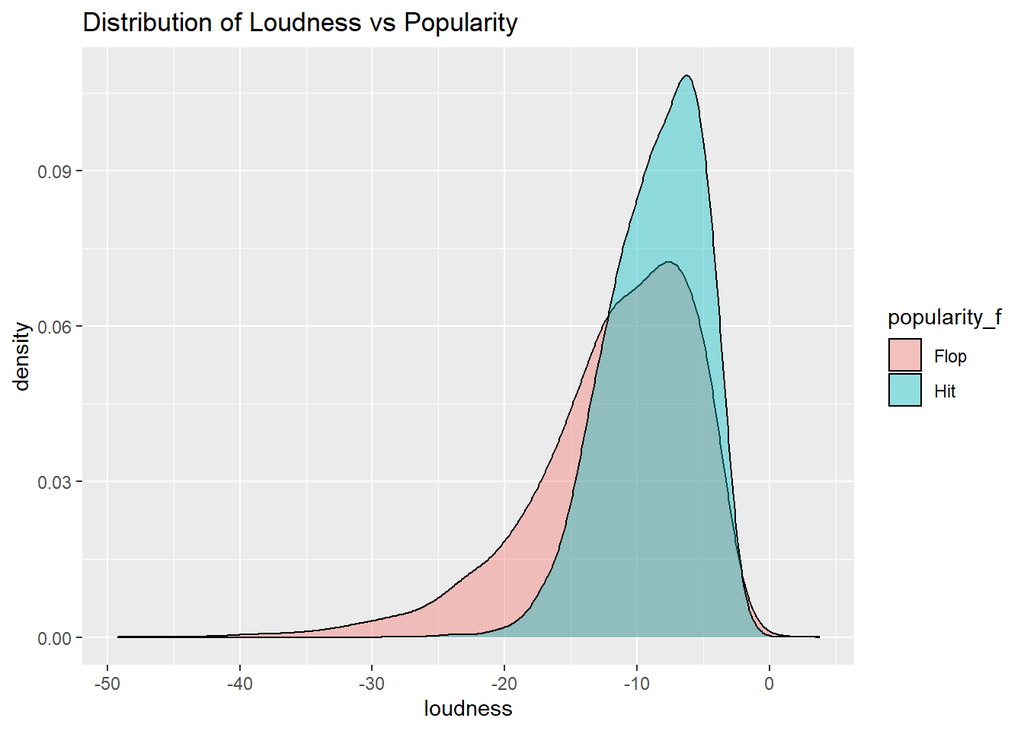

```r
ggplot(song_table,aes(x=loudness,fill=popularity_f))+
  geom_density(adjust = 1.5,alpha=.4)+
  labs(title="Distribution of Loudness vs Popularity")
```

The peak density for both Hit and Flop songs are in similar locations but Hits have a smaller distribution at a quieter volume.

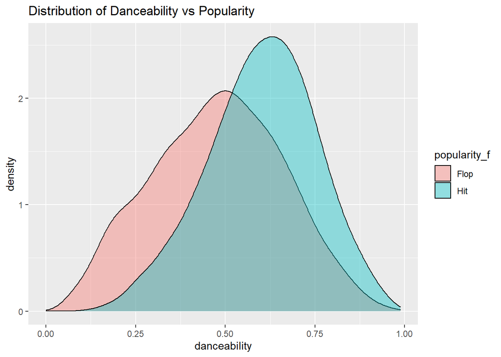

```r
ggplot(song_table,aes(x=danceability,fill=popularity_f))+
  geom_density(adjust = 1.5,alpha=.4)+
  labs(title="Distribution of Danceability vs Popularity")
```

Danceability of Hit songs tend to be higher than Flops.